# A Quiet Revolution, an Uneven Map, and a Pandemic

Four decades of childhood vaccination, told in four beats

Author

Team 15

Published

May 26, 2026

**Communication goals.** This prototype walks the reader through four beats: (1) the dramatic global rise in childhood vaccination since 1980, (2) the inequalities that persist beneath the global average, (3) the structural — especially economic — drivers of those inequalities, and (4) how the COVID-19 pandemic disrupted decades of progress. Each beat is one chart, one paragraph of narration, and one or two annotations that point directly to the evidence on the chart.

## A quiet revolution, 1980–2024

In 1980, fewer than one in five children worldwide was vaccinated against diphtheria, tetanus, and pertussis. Today, the figure is more than four in five. That shift — from **20%** to **85%** in just over four decades — ranks among the largest public-health gains in modern history, yet it rarely shows up in headlines. We open the story there: with the long arc that all of the later complications hang from.

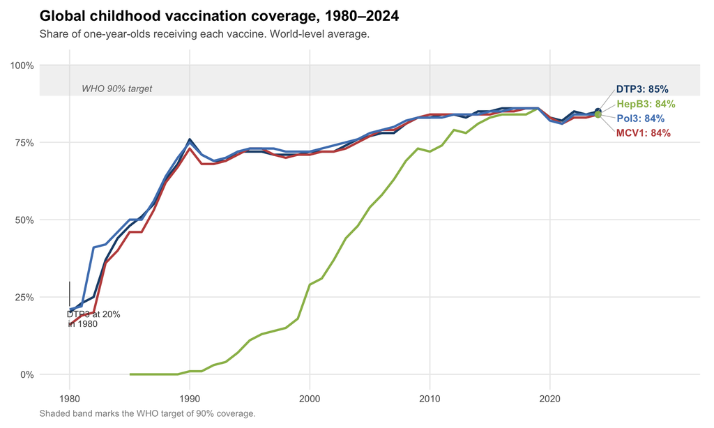

Source: WHO / UNICEF Estimates of National Immunization Coverage, via Our World in Data.

Four of the workhorse vaccines tell the same story. Diphtheria-tetanus-pertussis and polio both crossed the 75% line by 1990 — within a decade of the WHO’s Expanded Programme on Immunization gaining momentum. Hepatitis B took longer because it was added to the routine schedule later, but it has effectively caught up. The global picture, in short, looks like a success.

## But “global average” hides a lot

A single global line is reassuring, and misleading. Average coverage in 2024 sits at 85%, but the spread *between* countries is still enormous: nearly **60 percentage points** separate the best- and worst-performing nations. The map below shows where those gaps live. Two African neighbours, **Rwanda (98%)** and **Sudan (39%)**, sit at opposite ends of the scale in the same year.

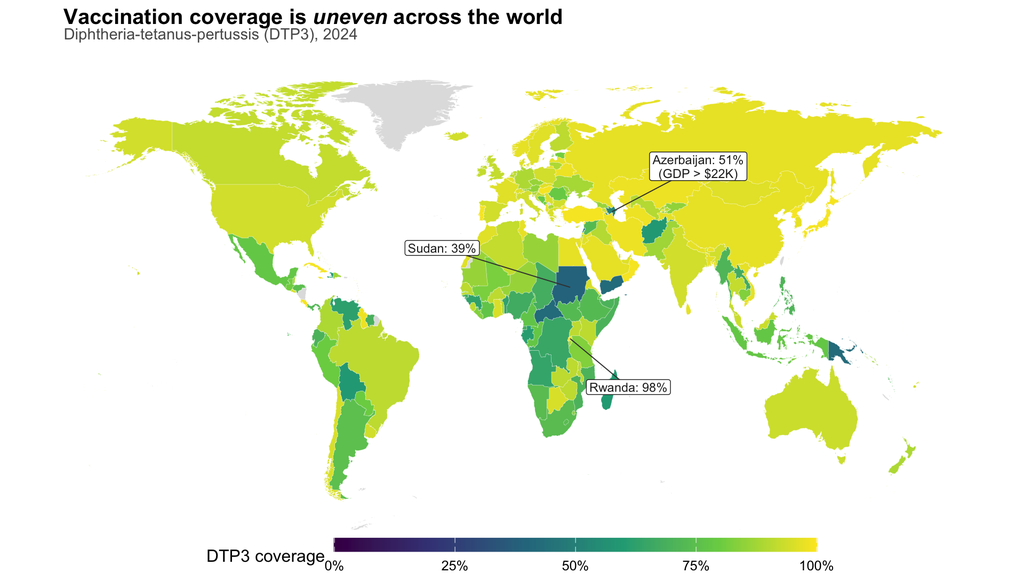

DTP3 coverage among one-year-olds in 2024. Grey = no data reported.

The low-coverage band runs through the Sahel, the Horn of Africa, and a handful of conflict-affected states; the high-coverage band covers nearly all of Europe, the Americas, and East Asia. But coverage is not destiny: Rwanda’s 98% rate, achieved at a GDP per capita under $3,500, sits next to wealthy **Azerbaijan’s 51%** — a result that should be impossible if vaccination were simply a question of money.

## Money matters — but it isn’t the whole story

If wealth alone determined vaccination, every country would line up neatly along a single curve. They don’t. Coverage *does* climb with GDP per capita, but the cloud of dots is wide enough that nearly every income level contains both stars and laggards. The trend is real but loose: a Pearson correlation of roughly **r ≈ 0.5** between log-GDP and DTP3 coverage in 2024.

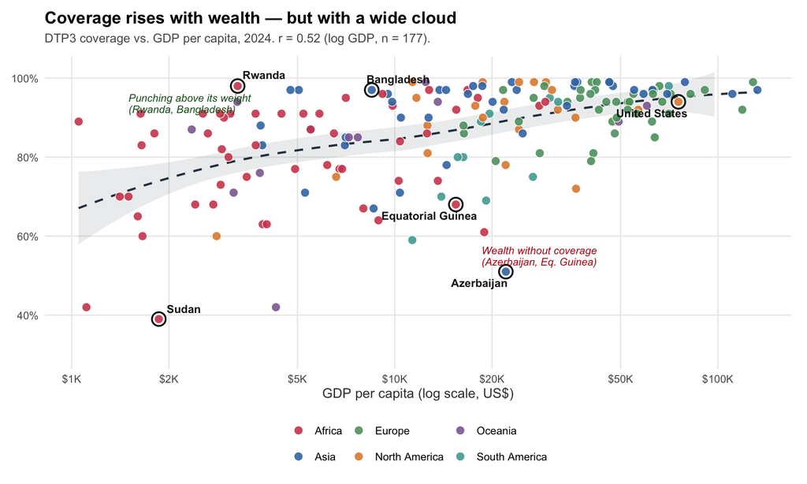

GDP per capita on a log scale. Dashed line is a loess fit with 95% CI.

The labelled countries are the story. **Rwanda** and **Bangladesh** sit far above the trend line: poor by world-bank measures, but with delivery systems strong enough to reach essentially every infant. On the other side, **Azerbaijan** and **Equatorial Guinea** are oil-rich and yet vaccinate at rates more typical of much poorer countries. Money helps, but what really seems to matter is whether a country has a functioning primary-care network to *use* the money for routine immunization.

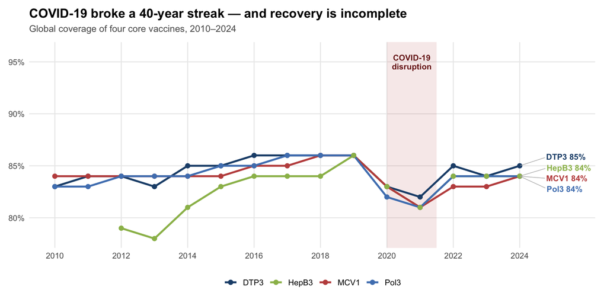

Four core vaccines, global average. WHO/UNICEF estimates.

## What this means — and what to do next

Each beat is built directly from the WHO/UNICEF Estimates of National Immunization Coverage (1980–2024) and World Bank GDP per capita data.

### Now you explore

The static narrative above takes the same dataset and turns it into four guided moments. The companion dashboard inverts that: it hands the wheel to the reader. Pick any vaccine, drag through any year, click any country to see its full trajectory and compare it to the world average.

> **→ Run the dashboard:** `Rscript -e 'shiny::runApp("dashboard")'` from the `information_visualization/` folder, or open `dashboard/app.R` in RStudio and click **Run App**.

**TipMethods and caveats**

- **Population denominator.** Coverage figures describe the share of one-year-olds who received each vaccine in that calendar year — not the share of the whole population.
- **Missing values are kept as gaps**, not zeros. For newer vaccines (PCV3, Rotavirus, IPV1) a blank cell typically means the vaccine wasn’t yet on the routine schedule.
- **Recent years are partly estimated.** WHO extrapolates from prior reporting when countries don’t report on time, so 2023–2024 numbers should be treated as best-available rather than firm.
- **GDP data starts in 1990.** Any cross-data analyses pre-1990 use only the vaccine series.